# Lecture 14: Subset Selection

PSTAT100: Data Science — Concepts and Analysis

John Inston

johninston@ucsb.edu

University of California, Santa Barbara

October 29, 2026

## 🚁 Overview

### Aims of the lecture

- Understand what **“optimal” model** means and why it depends on your goal.
- Introduce the **bias-variance tradeoff** as the central tension in model selection.
- Survey **subset selection** strategies: best subsets, forward, backward, and hybrid stepwise.
- Use **information criteria** (AIC, BIC, adjusted $R^2$) to compare models.

### 📚 Required Libraries

```python
import numpy as np
import pandas as pd
import matplotlib.pyplot as plt
import seaborn as sns

import statsmodels.formula.api as smf
import statsmodels.api as sm

from sklearn.datasets import fetch_california_housing
```

### 💅 Figure Styles

```python
sns.set_style('whitegrid')
sns.set_palette('Set2')
```

# Framing the Problem

## 🎯 What Does “Optimal” Model Mean?

### The goal depends on the task

| Goal | What matters | Implication |
| --- | --- | --- |
| **Prediction accuracy** | Low out-of-sample error | Can tolerate many predictors if they help |
| **Interpretability** | Sparse, readable model | Prefer fewer, meaningful predictors |
| **Inference validity** | Correct standard errors | Need well-specified, parsimonious model |
| **Parsimony** | Fewest predictors possible | Occam’s razor; generalisability |

> There is no universal “best” model — only models that are better suited to a given purpose. **The criterion you use to select a model should match the criterion you care about.**

## The Bias-Variance Tradeoff

For any estimator $\hat{f}$ of $f$, the expected test error at a point $x_0$ decomposes as:

$$\mathbb{E}\!\left[(Y - \hat{f}(x_0))^2\right]
= \underbrace{\left(\mathbb{E}[\hat{f}(x_0)] - f(x_0)\right)^2}_{\text{Bias}^2}
+ \underbrace{\mathrm{Var}(\hat{f}(x_0))}_{\text{Variance}}
+ \underbrace{\sigma^2}_{\text{Irreducible error}}.$$

- **Bias**: systematic error from using the wrong model class — underfitting.
- **Variance**: sensitivity to the particular training sample — overfitting.
- $\sigma^2$: noise in the data itself; cannot be reduced by any model.

> Adding predictors **reduces bias** (the model fits more patterns) but **inflates variance** (the model memorises the training data). The tradeoff is managed by choosing model complexity wisely.

## Bias-Variance Tradeoff — Visualization

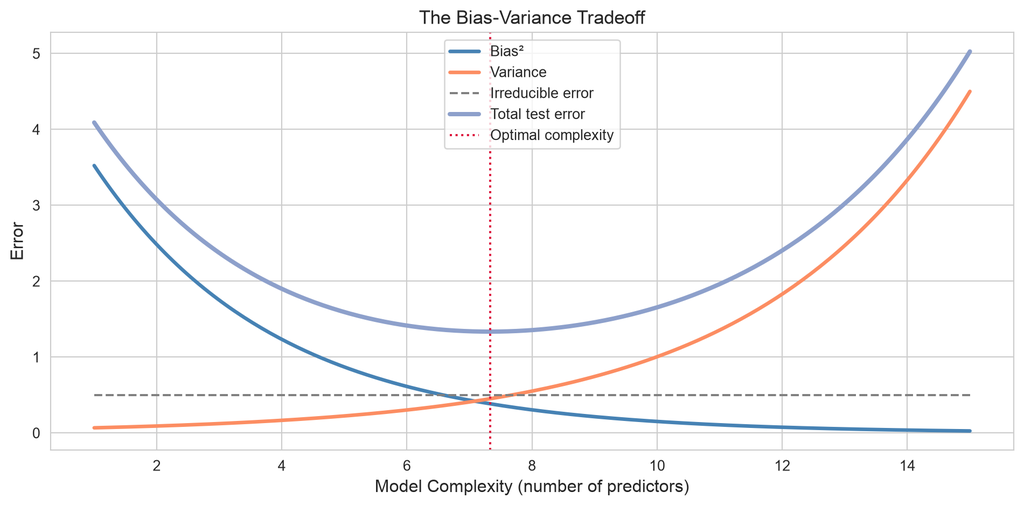

The bias-variance tradeoff. As model complexity grows, bias falls but variance rises. The optimal complexity minimises total test error.

## Overfitting vs. Underfitting

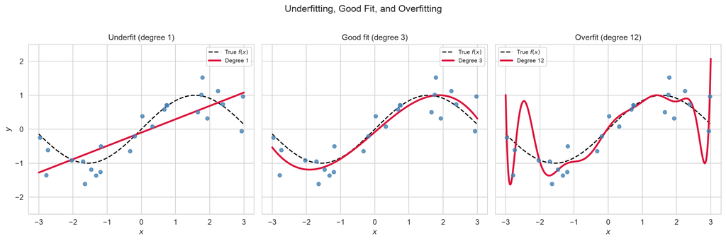

Underfitting (degree 1): the model misses real structure. Overfitting (degree 12): the model chases noise. A degree-3 polynomial captures the true pattern well.

# Prerequisite Review

## The MLR Model

**Multiple Linear Regression**

$$\mathbf{y} = \mathbf{X}\boldsymbol{\beta} + \boldsymbol{\varepsilon}, \qquad \boldsymbol{\varepsilon} \sim \mathcal{N}(\mathbf{0},\, \sigma^2 \mathbf{I}_n),$$

where $\mathbf{y} \in \mathbb{R}^n$, $\mathbf{X} \in \mathbb{R}^{n \times (p+1)}$ (including an intercept column), and $\boldsymbol{\beta} \in \mathbb{R}^{p+1}$.

The **OLS estimator** is:

$$\hat{\boldsymbol{\beta}} = (\mathbf{X}^\top \mathbf{X})^{-1}\mathbf{X}^\top \mathbf{y}.$$

### Key quantities

| Symbol | Formula | Role |
| --- | --- | --- |
| $\hat{\mathbf{y}}$ | $\mathbf{X}\hat{\boldsymbol{\beta}} = \mathbf{H}\mathbf{y}$ | Fitted values |
| $\mathbf{H}$ | $\mathbf{X}(\mathbf{X}^\top\mathbf{X})^{-1}\mathbf{X}^\top$ | Hat (projection) matrix |
| $h_{ii}$ | $[\mathbf{H}]_{ii}$ | Leverage of observation $i$ |
| $\text{RSS}$ | $\mathbf{e}^\top\mathbf{e} = \\|\mathbf{y} - \hat{\mathbf{y}}\\|^2$ | Residual sum of squares |

## The Hat Matrix and Leverage

The hat matrix $\mathbf{H}$ is an **orthogonal projector** onto $\text{col}(\mathbf{X})$:

- $\mathbf{H}^2 = \mathbf{H}$ (idempotent), $\mathbf{H}^\top = \mathbf{H}$ (symmetric).
- $\hat{\mathbf{y}} = \mathbf{H}\mathbf{y}$; residuals $\mathbf{e} = (\mathbf{I} - \mathbf{H})\mathbf{y}$.
- $\text{tr}(\mathbf{H}) = p + 1$ (the number of parameters).

### Leverage $h_{ii}$

- $h_{ii} \in [1/n,\, 1]$; observation $i$ has **high leverage** if its predictor values are far from the centroid of $\mathbf{X}$.
- High leverage alone does not mean the point is influential — it needs to also have a large residual.

> We will see that $h_{ii}$ reappears in the LOOCV formula, making leverage a bridge between geometry, influence, and cross-validation.

## MLR Assumptions

| Assumption | Statement | Consequence if violated |
| --- | --- | --- |
| **Linearity** | $\mathbb{E}[\mathbf{y}] = \mathbf{X}\boldsymbol{\beta}$ | Systematic bias in $\hat{\boldsymbol{\beta}}$ |
| **Homoscedasticity** | $\text{Var}(\varepsilon_i) = \sigma^2$ for all $i$ | Inefficient OLS; SEs wrong |
| **No multicollinearity** | $\mathbf{X}^\top\mathbf{X}$ is invertible (ideally well-conditioned) | Inflated variances of $\hat{\boldsymbol{\beta}}$ |
| **Exogeneity** | $\mathbb{E}[\boldsymbol{\varepsilon} \mid \mathbf{X}] = \mathbf{0}$ | OLS is biased |
| **Normality** | $\boldsymbol{\varepsilon} \sim \mathcal{N}(\mathbf{0}, \sigma^2 \mathbf{I})$ | Needed for finite-sample inference |

# Subset Selection Methods

## 🔍 The Subset Selection Problem

### The setup

- We have $p$ candidate predictors. How do we choose which to include?
- There are $2^p$ possible subsets — including the intercept-only model and the full model.

### Four strategies

1. **Best subset**: evaluate all $2^p$ subsets, pick the one minimising an information criterion.
2. **Forward stepwise**: start from the null model, add one predictor at a time.
3. **Backward stepwise**: start from the full model, drop one predictor at a time.
4. **Hybrid**: allow both additions and removals at each step.

> For $p \leq 20$ or so, best subset is feasible. For $p \gtrsim 30$, stepwise or regularization is preferred.

## Best Subset Selection

### Algorithm

For each $k = 0, 1, \ldots, p$:

1. Fit all $\binom{p}{k}$ models with exactly $k$ predictors.
2. Save the best (lowest RSS) model of size $k$: call it $\mathcal{M}_k$.

Then select among $\mathcal{M}_0, \mathcal{M}_1, \ldots, \mathcal{M}_p$ using a criterion such as AIC, BIC, or adjusted $R^2$.

### Computational cost

- $p = 10$: $2^{10} = 1024$ models — trivial.
- $p = 20$: $2^{20} \approx 10^6$ models — manageable.
- $p = 40$: $2^{40} \approx 10^{12}$ models — **infeasible**.

> Best subset selection is the gold standard for small $p$, but its exponential cost means stepwise methods or regularization are needed for moderate to large $p$.

## Forward Stepwise Selection

### Algorithm

1. Start with the null model $\mathcal{M}_0$ (intercept only).
2. At each step, **add** the predictor that most improves a criterion (e.g., largest $|t|$-statistic, smallest AIC, or largest decrease in RSS).
3. Stop when no addition improves the criterion — or when all $p$ predictors are added.

> What would this look like in `python`?

## Forward Stepwise Implementation in Python

```python
def forward_stepwise(y, X_candidates, criterion='aic'):
    """
    Greedy forward stepwise selection.
    y: pd.Series, X_candidates: pd.DataFrame (predictors only, no intercept)
    Returns a list of selected predictor names.
    """
    remaining  = list(X_candidates.columns)  # predictors not yet in the model
    selected   = []                           # predictors chosen so far
    best_score = np.inf                       # track the best criterion seen

    while remaining:
        # Try adding each remaining predictor to the current selected set
        scores = {}
        for col in remaining:
            cols  = selected + [col]               # candidate set with one addition
            X_fit = sm.add_constant(X_candidates[cols])
            res   = sm.OLS(y, X_fit).fit()
            scores[col] = getattr(res, criterion)  # AIC (or BIC) of this candidate

        # Pick whichever addition gave the lowest criterion value
        best_col = min(scores, key=scores.get)
        best_new = scores[best_col]

        if best_new < best_score:       # adding best_col actually improved the fit
            best_score = best_new
            selected.append(best_col)   # commit the addition
            remaining.remove(best_col)
        else:
            break   # no remaining predictor improves the criterion: stop

    return selected
```

## Backward Stepwise Selection

### Algorithm

1. Start with the full model $\mathcal{M}_p$ (all $p$ predictors).
2. At each step, **drop** the predictor with the smallest $|t|$-statistic (or largest $p$-value, or that decreases AIC most).
3. Stop when no removal improves the criterion.

## Backward Stepwise Implementation in Python

```python
def backward_stepwise(y, X_candidates, criterion='aic'):
    """
    Greedy backward stepwise selection.
    """
    selected = list(X_candidates.columns)  # start with all predictors in the model

    # Score the full model as the initial benchmark
    X_fit      = sm.add_constant(X_candidates[selected])
    best_score = getattr(sm.OLS(y, X_fit).fit(), criterion)

    improved = True
    while improved and len(selected) > 1:   # stop if no improvement or only intercept left
        improved = False
        scores   = {}

        # Try dropping each predictor and score the resulting smaller model
        for col in selected:
            cols  = [c for c in selected if c != col]  # all predictors except col
            X_fit = sm.add_constant(X_candidates[cols])
            res   = sm.OLS(y, X_fit).fit()
            scores[col] = getattr(res, criterion)      # criterion when col is removed

        # Find the predictor whose removal most improves (lowers) the criterion
        drop_col   = min(scores, key=scores.get)
        drop_score = scores[drop_col]

        if drop_score < best_score:        # dropping drop_col actually helped
            best_score = drop_score
            selected.remove(drop_col)      # commit the removal
            improved   = True              # signal that another pass should be tried

    return selected
```

## Comparing Forward and Backward Stepwise

| Property | Forward | Backward |
| --- | --- | --- |
| Start | Null model | Full model |
| Requires $n > p$? | No | **Yes** (full model must be estimable) |
| Can re-include dropped predictors? | No | No |
| Can drop previously added predictors? | No | No |

### Hybrid stepwise

- At each step, consider **both** additions and removals.
- Implemented by alternating forward and backward passes.
- More flexible, but still greedy — not guaranteed to find the globally optimal subset.

> **Caution**: stepwise selection inflates Type I error and produces overoptimistic $p$-values — it should be used for **model building**, not for inference. Report final model uncertainty honestly.

# Information Criteria

## 📏 Penalised Likelihood Criteria

### The general idea

- RSS always decreases as we add predictors — using it alone leads to the full model.
- Information criteria add a **penalty for model complexity** to discourage overfitting.

**AIC and BIC**

$$\text{AIC} = -2\ell(\hat{\boldsymbol{\beta}}) + 2k$$

$$\text{BIC} = -2\ell(\hat{\boldsymbol{\beta}}) + k\ln n$$

where $\ell(\hat{\boldsymbol{\beta}})$ is the maximised log-likelihood, $k$ is the number of free parameters (including $\sigma^2$), and $n$ is the sample size. **Lower is better.**

- **AIC** (Akaike, 1974): derived from information-theoretic arguments; estimates out-of-sample prediction error.
- **BIC** (Schwarz, 1978): derived from Bayesian arguments; penalises $k$ more heavily when $n$ is large.
- For $n \geq 8$, $\ln n > 2$, so **BIC penalises harder** and tends to favour sparser models.

## AIC vs. BIC in Practice

```python
n_vals = np.arange(8, 1001)
fig, ax = plt.subplots(figsize=(9, 4))
ax.plot(n_vals, 2 * np.ones_like(n_vals), lw=2.5,
        color='steelblue', label='AIC penalty per parameter (constant = 2)')
ax.plot(n_vals, np.log(n_vals), lw=2.5,
        color='#fc8d62', label='BIC penalty per parameter ($\\ln n$)')
ax.set_xlabel('Sample size $n$')
ax.set_ylabel('Penalty per parameter')
ax.set_title('AIC vs. BIC: Penalty Per Parameter')
ax.legend(fontsize=10)
plt.tight_layout(); plt.show()
```

## AIC vs. BIC in Practice

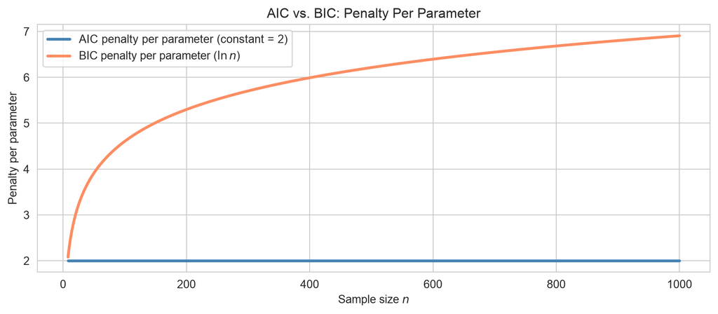

AIC vs BIC penalty as a function of sample size. BIC penalises each additional parameter more heavily, growing without bound as n increases.

## Adjusted $R^2$

Ordinary $R^2 = 1 - \text{RSS}/\text{TSS}$ increases whenever a predictor is added, even if that predictor is irrelevant.

**Adjusted $R^2$** corrects for this:

$$\bar{R}^2 = 1 - \frac{\text{RSS}/(n - p - 1)}{\text{TSS}/(n-1)} = 1 - \frac{n-1}{n-p-1}(1 - R^2).$$

- Adding a predictor increases $\bar{R}^2$ **only if** it reduces the residual variance more than expected by chance.
- Unlike AIC/BIC, higher $\bar{R}^2$ is better.
- Asymptotically, maximising $\bar{R}^2$ is equivalent to minimising AIC.

## Model Comparison Table in Python

```python
# Load data and fit a sequence of models for illustration
housing = fetch_california_housing(as_frame=True)
df = housing.frame.copy()
df.columns = [c.lower() for c in df.columns]

# Fit models of increasing complexity
formulas = {
    'Intercept only':         'medhouseval ~ 1',
    '+ MedInc':               'medhouseval ~ medinc',
    '+ MedInc + HouseAge':    'medhouseval ~ medinc + houseage',
    '+ MedInc + HouseAge\n+ AveRooms + AveBedrms':
                              'medhouseval ~ medinc + houseage + averooms + avebedrms',
    'Full (all 8)':           'medhouseval ~ medinc + houseage + averooms + avebedrms'
                              ' + aveoccup + population + latitude + longitude',
}

rows = []
for name, formula in formulas.items():
    fit = smf.ols(formula, data=df).fit()
    rows.append({
        'Model': name.replace('\n', ' '),
        'k': int(fit.df_model) + 2,   # predictors + intercept + sigma²
        'R²': round(fit.rsquared, 4),
        'Adj. R²': round(fit.rsquared_adj, 4),
        'AIC': round(fit.aic, 1),
        'BIC': round(fit.bic, 1),
    })

cmp = pd.DataFrame(rows)
print(cmp.to_string(index=False))
```

## Model Comparison Table in Python

```
                                     Model  k      R²  Adj. R²     AIC     BIC
                            Intercept only  2 -0.0000  -0.0000 64485.9 64493.9
                                  + MedInc  3  0.4734   0.4734 51249.3 51265.2
                       + MedInc + HouseAge  4  0.5091   0.5091 49803.4 49827.2
+ MedInc + HouseAge + AveRooms + AveBedrms  6  0.5375   0.5374 48578.7 48618.4
                              Full (all 8) 10  0.6062   0.6061 45265.5 45337.0
```

## Conclusion

### ✅ What We Covered

- **Framing**: what “optimal” means depends on the goal — prediction, inference, interpretability.
- **Bias-variance tradeoff**: the central tension; more complexity lowers bias but inflates variance.
- **Subset selection**: best subsets, forward, backward, and hybrid stepwise.
- **Information criteria**: AIC, BIC, and adjusted $R^2$ as principled model comparison tools.

### 📅 What’s Next?

- **Cross-validation**: estimating out-of-sample error and selecting tuning parameters.
- **Regularization**: Ridge, Lasso, and Elastic Net for high-dimensional problems.
- **Multicollinearity**: diagnosing with VIF and condition numbers, and how regularization can help.
- **Model comparison**: partial $F$-tests for nested models.